# Introducción a distribuciones de probabilidad

Ramon Ceballos

8/2/2021

# **Distribución Uniforme**

## 1. Conceptos teóricos y matemáticos

Una v.a. continua **$X$** tiene distribución uniforme sobre el intervalo real $[a,b]$ con $a<b$, **$X\sim\text{U}(a,b)$** si su función de densidad es:
$$f_X(x)=\left\{
\begin{array}{rl}
\frac{1}{b-a} & \text{si } a\le x\le b
\\ 0 & \text{en cualquier otro caso}
\end{array}
\right.$$

Modela el elegir un elemento del intervalo $[a,b]$ de manera equiprobable.

Vamos a definir algunas de las propiedades que tendrá una distribución Uniforme.

- El **dominio** de $X$ será $D_X = [a,b]$.
- La **función de distribución** vendrá dada por:
  $$F_X(x)=\left\{
  \begin{array}{rl}
  0 & \text{si } x<a
  \\ \frac{x-a}{b-a} & \text{si } a\le x< b
  \\ 1 & \text{si } x\ge b
  \end{array}
  \right.$$
- **Esperanza** $E(X) = \frac{a+b}{2}$
- **Varianza** $Var(X) = \frac{(b-a)^2}{12}$

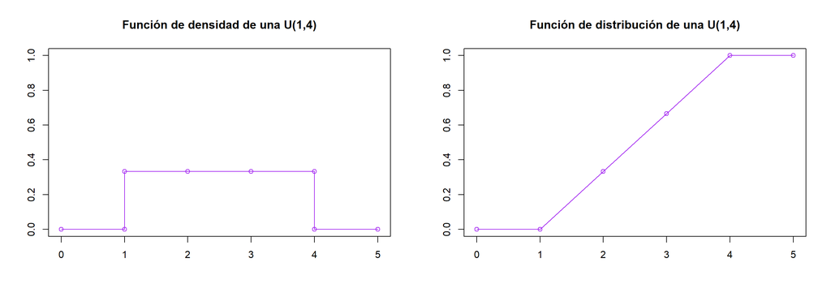

```r
par(mfrow=c(1,2))

#•Función de densidad
plot(c(0,1,1:4,4,5),
     c(0,0,dunif(1:4,min = 1, max = 4),0,0),
     col = "purple",
     xlab = "", ylab = "",
     main = "Función de densidad de una U(1,4)",
     type = "o",
     ylim = c(0,1))

#Función de distribución
plot(0:5,
     punif(0:5,min = 1, max = 4),
     col = "purple",
     xlab = "", ylab = "",
     main = "Función de distribución de una U(1,4)",
     type = "o")
```

```r
par(mfrow=c(1,1))
```

## 2. Distribución Uniforme en `R` y `Python`

El código de la distribución Uniforme:

- En **`R`** tenemos las funciones del paquete **`stats`**: **`dunif(x, min, max), punif(q, min, max), qunif(p, min, max), runif(n, min, max)`** donde `min` y `max` són los extremos de los intervalos de la distribución uniforme.
- En **`Python`** tenemos las funciones del paquete **`scipy.stats.uniform`**: **`pdf(k,loc, scale), cdf(k,loc, scale), ppf(q,loc, scale), rvs(n,loc, scaler)`** donde la distribución uniforme está definida en el intervalo `[loc, loc+scale]` **Cuidado**: `scale` es la amplitud del intervalo.

## 3. Ejemplos en código para la distribución Uniforme (R y Python)

Supongamos que $X\sim U([0,1])$ entonces podemos estudiar sus parámetros.

#### **Ejemplo en R**

Empleamos las funciones anteriores.

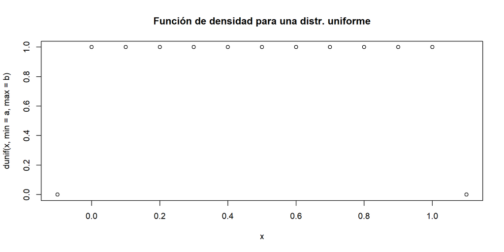

```r
#Definimos el primer punto (a) y el útimo (b)
a = 0
b = 1

#Generamos los valores para el eje "x"
x = seq(-0.1, 1.1, 0.1)

#Función de densidad
plot(x, dunif(x, min = a, max = b),
     title("Función de densidad para una distr. uniforme"))
```

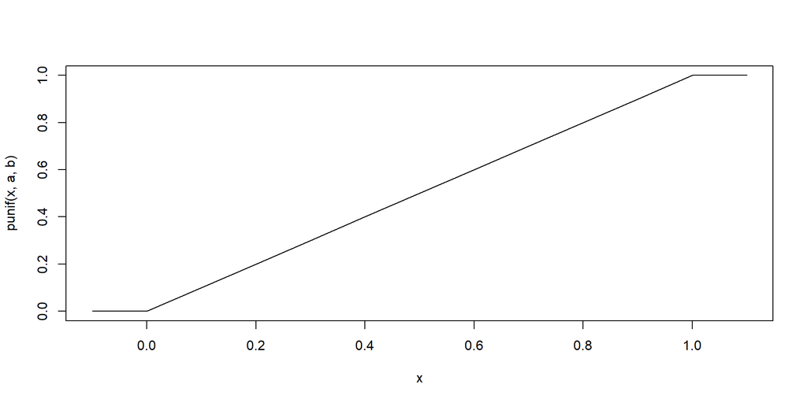

```r
#Función de distribución
plot (x, punif(x, a, b), type = "l")
```

```r
#La mediana
qunif(0.5, a, b)
```

```
## [1] 0.5
```

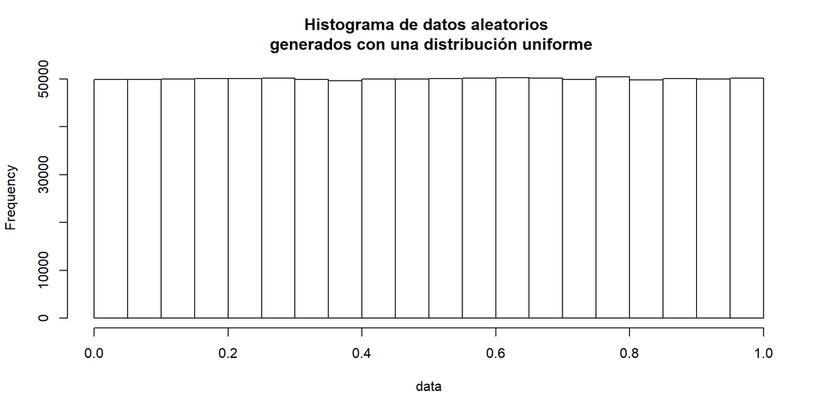

```r
#Generamos datos aleatorios seún la distribución uniforme
#Los representamos en un histograma
runif(1000000, a, b) -> data
hist(data,
     main = "Histograma de datos aleatorios \n generados con una distribución uniforme")
```

#### **Ejemplo en Python**

Vete al script de Python del presente tema 13.